# Mise en oeuvre du pilote automatique (crea)

## Présentation

Le système est composé :

[figure not shown]

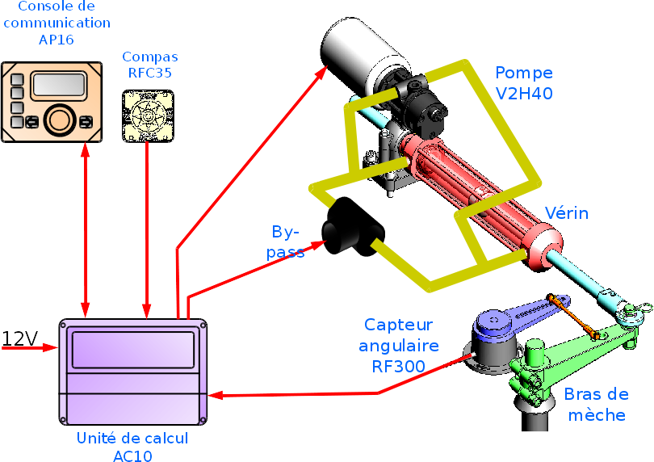

Lien : http://www.crea-technologie.com/index.php?product=10

## Objectifs

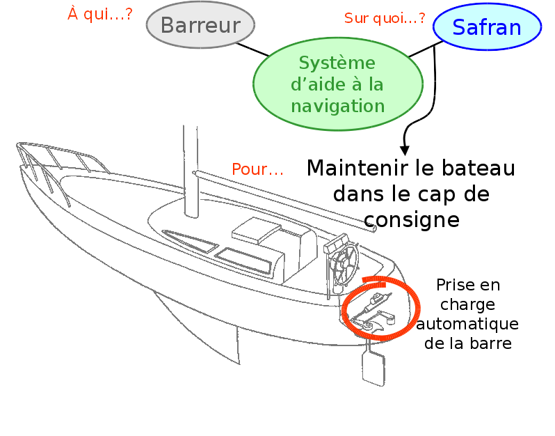

## Mise sous tension

Le système doit être alimenté sous 12V continu, avec une alimentation de calibre 12V-20A.

```
Attention, ne pas inverser la polarité !
```

Remarques :

- Un fusible 15A rapide est destiné à la protection du calculateur AC10 et de la console AP16
- Un fusible 500 mA assure la protection de l’afficheur débitmètre

A la mise sous tension de l’alimentation, l’afficheur débitmètre doit indiquer R0.00.

Appuyer sur le bouton STBY PWR de la console AP16.

[figure not shown]

## Fonctionnement rapide

La console AP16 associée aux autres instruments a été paramétrée pour un déplacement du vérin linéaire à +/- 35°.

L’entrée et la sortie de tige s’effectuent en pressant les touches Bâbord et Tribord de la console AP16 (touches 1 verte et 1 rouge).

Mode automatique : Presser la touche auto. Pour sortir du mode, presser la touche STBY PWR.

Documentations : SIMRAD.zip et heading_solidstate_nmea2000.pdf

## Communication Bus CAN/NMEA2000

Lire Bus CAN/NMEA 2000 avant de poursuivre.

Le calculateur émet périodiquement des messages PGN 127250 qui contiennent le cap du navire.

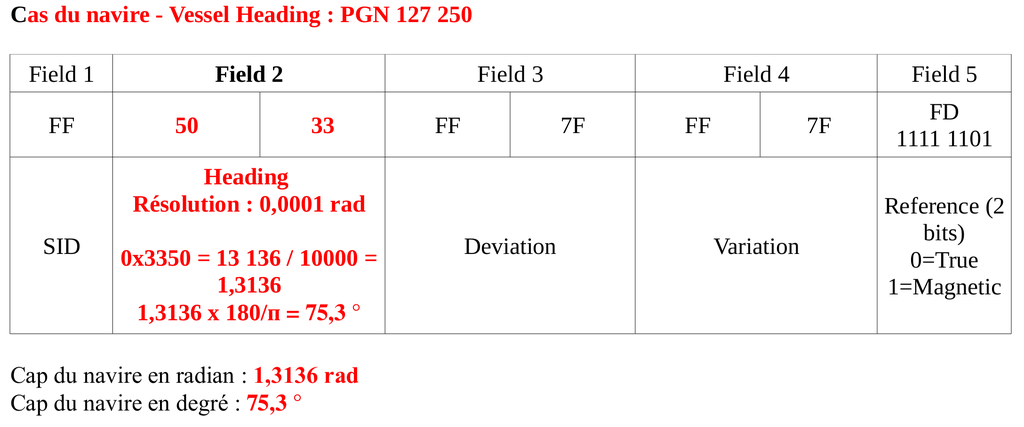

Documentation : SimNet-NMEA2000.pdf

## Travail demandé

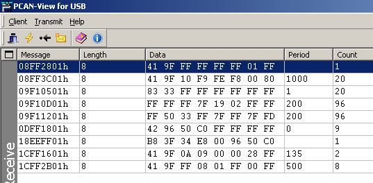

1. Déterminer les identifiants des messages capturés qui correspondent aux PGN 127245 et 127250.
2. Déterminer l’angle de barre en radian puis en degré.

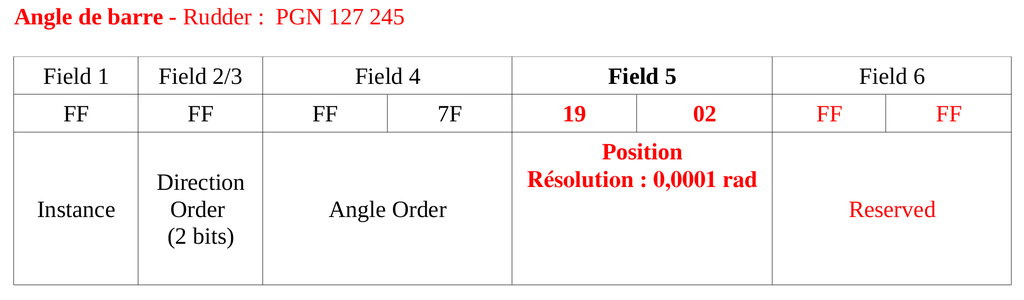

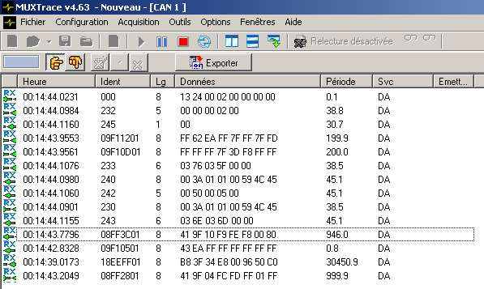

3. Capturer un message PGN 127250 et déterminer le cap du navire en radian puis en degré.
4. Combien de messages PGN 127250 et 127245 sont émis par seconde.

Retour au sommaire